# Demand Side II: Firms, Platforms, and Lobbying

POLISCI 158 · AI & Politics · Session 4 · Mon, Oct 5, 2026

Simone Paci

## Roadmap

1. Firms: political power and product safety
   - Ask when market discipline needs public regulation
2. Six channels of political influence
   - Identify a mechanism and evaluate the evidence in an AI case
3. Access, labs and competing principals
   - Compare model access and competing principal–agent relationships

# Part I: Firms, power and product safety

## Why look at AI firms?

**Political economy**

AI becomes more important. Which firms gain resources and political power?

**Product safety**

Who bears the risks? Are market discipline and liability enough?

## Firms have strong policy interests

A firm’s business model gives it reasons to care about policy.

**Labor**

Who can do the work, and on what terms?

**Finance**

Who pays for expansion, and who bears the risk?

**Market rules**

Who can enter, compete and reach users?

## Who solves the collective-action problem?

- Money to sustain an effort
- Technical knowledge and specialist staff
- Fewer actors to coordinate
- Dispersed benefits can encourage free riding

Having resources does not prove that a firm gets its way.

Mancur Olson, [The Logic of Collective Action](https://doi.org/10.4159/9780674041660), 1965. Shared interests do not automatically produce collective action.

## What happened with the last Industrial Revolution?

[figure not shown]

Frederick Burr Opper, [Let Them Have It All, And Be Done With It!](https://digital.library.cornell.edu/catalog/ss:3293889), *Puck*, 1882. Cornell University Library, P.J. Mode Collection.

## Antitrust: laws and a court remedy

**1890**

Sherman Act

- Prohibited restraints of trade and monopolization.
- Created a federal basis for action against trusts.

**1911**

Standard Oil dissolution upheld

- The Supreme Court affirmed the dissolution order.
- Standard Oil had to separate its constituent companies.

**1914**

Clayton Act

- Targeted specific practices that could reduce competition.
- Addressed mergers and interlocking directorates.

[National Archives: Sherman Act](https://www.archives.gov/milestone-documents/sherman-anti-trust-act); [Standard Oil, 221 U.S. 1](https://tile.loc.gov/storage-services/service/ll/usrep/usrep221/usrep221001/usrep221001.pdf), pp. 1, 80–82; [FTC: the antitrust laws](https://www.ftc.gov/advice-guidance/competition-guidance/guide-antitrust-laws/antitrust-laws).

## Will the market keep AI safe?

**The market-discipline argument**

- Unsafe products lose customers.
- Reputation and liability deter risk-taking.

**The questions to test**

- Can customers recognize the risk?
- Who bears harms outside the transaction?

## Did social media protect young users?

**A familiar product-safety problem**

Facebook and Instagram: children’s safety, product design and what users were told.

**An external response**

States challenged platform designs; litigation led to judgments and a multistate settlement framework.

[New Mexico v. Meta, trial-court judgment](https://nmdoj.gov/wp-content/uploads/D-101-CV-2023-02838-Meta-Judgement.pdf), filed August 6, 2026.

## What changed when states intervened?

**New Mexico judgment**

$942m

Civil penalties + abatement funding

**Multistate settlement framework**

Up to $17bn

Payments over ten years

**Product rules:** teen time limits, overnight blocks and independent monitoring.

[New Mexico judgment](https://nmdoj.gov/wp-content/uploads/D-101-CV-2023-02838-Meta-Judgement.pdf), August 6, 2026; [California AG’s framework announcement](https://www.oag.ca.gov/news/press-releases/attorney-general-bonta-secures-transformative-17-billion-settlement-meta), August 26; [North Carolina reports its first payment](https://ncdoj.gov/meta-pays-more-than-45-million-in-first-payment-to-nc-from-attorney-general-jacksons-landmark-settlement/), October 1.

# Part II: Six channels of influence

## 1. Campaign finance and candidate selection

**Resources** → **Campaign messages** → **Candidate incentives**

- Who receives support? Who faces opposition?
- Which policy dispute becomes an election issue?
- What would show that spending changed the result?

## NY-12: a policy dispute enters a primary

- **Alex Bores:** Assembly sponsor of the RAISE bill
- **Think Big PAC:** committee behind the attack ad
- **The dispute:** rules for frontier AI developers

RAISE was enacted in 2025 and amended in March 2026. The amended act sets January 1, 2027 as its effective date.

[New York Assembly, June 13, 2025](https://assembly.ny.gov/Press/?sec=story&story=114369); [New York Senate, S8828](https://www.nysenate.gov/legislation/bills/2025/S8828), actions and §3; [Think Big PAC, FEC C00923417](https://www.fec.gov/data/committee/C00923417/?cycle=2026).

## Two sides, two messages

[figure not shown]

**Think Big PAC**

[Alex Bores is Wrong for AI & Wrong for Congress](https://www.youtube.com/watch?v=IpPL7jY-9pI)

[figure not shown]

**Alex Bores for Congress**

[Stop Us](https://www.youtube.com/watch?v=U5xxexw1jT4)

Who is the audience? What claim should we check?

Campaign videos, 2026; stills illustrate the speakers’ messages. Linked playback requires internet.

## Do influence campaigns always win?

**Micah C. Lasher**

41,940

votes

**Alex Bores**

37,637

votes

**Observed:** Lasher won the primary.

**Unanswered:** what would have happened without the spending?

[NYC Board of Elections, certified NY-12 Democratic primary return](https://www.vote.nyc/sites/default/files/pdf/election_results/2026/20260623Primary%20Election/01101600012New%20York%20Democratic%20Representative%20in%20Congress%2012th%20Congressional%20District%20Recap.pdf), pp. 10–12; certified July 14, 2026. Named-candidate lines shown.

## 2. Lobbying: information and persuasion

**Information**

Expertise, policy drafts and constituency knowledge

versus

**Persuasion**

Arguments about costs, benefits and priorities

## AI lobbying grew — what are we counting?

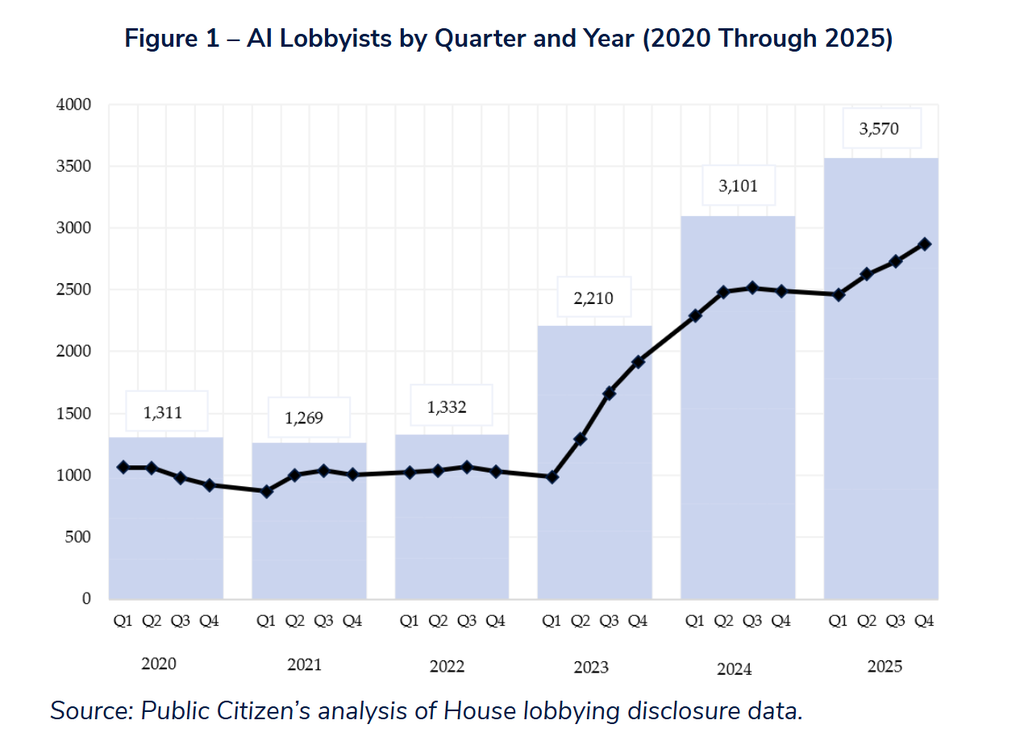

**Unique people**

1,332 → 3,570

2022 → 2025

**About +168%**

Public Citizen, [Generative Influence](https://www.citizen.org/article/generative-influence/), Feb 24, 2026, Figure 1 and Table 1. Search includes AI, autonomous vehicles/systems and data centers.

## 3. The revolving door

**Government staff** ⇄ **Corporate staff**

- Knowledge of how institutions work
- Professional networks and access
- Preferences carried between organizations

What would separate expertise from preferential access?

## Who has access to the administration?

[figure not shown]

[White House technology-leaders dinner](https://www.whitehouse.gov/gallery/president-donald-trump-and-first-lady-melania-trump-host-business-and-technology-leaders-for-a-dinner-in-state-dining-room-at-the-white-house/), September 4, 2025. Official photograph by Andrea Hanks; displayed crop.

## 4. Private governance: can firms preempt regulation?

**Voluntary rules** → **Less demand for public intervention?**

- Firms can respond before governments impose rules.
- Visible self-regulation may reassure voters and officials.
- Industry-wide participation makes the signal harder to dismiss.

Malhotra, Monin & Tomz, [Does Private Regulation Preempt Public Regulation?](https://doi.org/10.1017/S0003055418000679), *APSR* 113(1), 2019.

## Private governance in practice: Project Glasswing

**Anthropic sets conditions for access**

- Selected partners received Claude Mythos Preview for defensive cybersecurity
- Anthropic committed up to **$100m in usage credits**
- Expanded access still required Anthropic’s security conditions

Who sets the conditions, and who checks compliance?

[Anthropic, Project Glasswing](https://www.anthropic.com/project/glasswing), Apr 7, 2026 launch description. Company announcement; credits are not cash disbursed.

## A White House accord: voluntary oversight

**Six firms signed the September 2026 accord.**

**Inside the firm**

Internal controls + an empowered oversight team

**Outside management**

Independent evaluator + independent board committee

**Who monitors the commitments? What follows a breach?**

[White House Accord on Super Intelligence](https://www.presidency.ucsb.edu/documents/white-house-accord-super-intelligence), September 29, 2026. Google, Anthropic, Meta, OpenAI, xAI and NVIDIA; voluntary commitments.

## 5. Narrative power

**A company frames the policy problem**

- OpenAI calls for mandatory national safety requirements
- Its proposal ties rules to model capabilities
- The framing invites government action

Which interests become visible? Which fade into the background?

Chris Lehane, OpenAI, [The AI policy window is open. We need to act.](https://openai.com/index/ai-policy-window/), Sep 9, 2026. An attributable company position.

## Two companies, two narratives

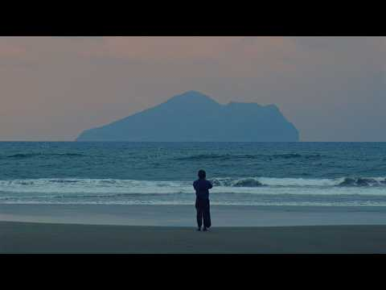

**Anthropic: “There’s hope in hard questions”**

[Watch the film](https://www.youtube.com/watch?v=jVbGX7zJHi8)

[figure not shown]

**Jensen Huang × Ezra Klein**

[Watch the interview](https://www.youtube.com/watch?v=HjurAWAr_nY)

[Anthropic campaign](https://www.anthropic.com/news/hard-questions), July 2026; *The Ezra Klein Show*, September 23, 2026. Click a poster for online playback.

## 6. Workplace politics

**Workers can contest their employer’s choices**

- DeepMind staff sought union recognition
- CWU reported demands about moral refusal and ethics oversight
- Management rejected voluntary recognition; talks were planned

[Communication Workers Union, May 20, 2026](https://www.cwu.org/press_release/google-ai-workers-to-enter-union-recognition-talks/). A dated union account; no completed recognition is claimed.

## Who speaks out from inside the labs?

**Public departures and warnings**

- **William Saunders** · OpenAI safety/testing concerns
- **Daniel Kokotajlo** · OpenAI governance concerns
- **Jan Leike** · OpenAI Superalignment resignation
- **Geoffrey Hinton** · left Google to discuss AI risks

**Selected collective statements**

- [Pause Giant AI Experiments](https://futureoflife.org/open-letter/pause-giant-ai-experiments/) · 2023
- [Statement on AI Risk](https://safe.ai/work/statement-on-ai-extinction-risk) · 2023
- [A Right to Warn](https://righttowarn.ai/) · 2024
- [Saunders–Kokotajlo: SB1047](https://static.politico.com/ed/a3/b49946554f5ead081a5df2063048/letter-from-openai-whistleblowers-on-sb-1047-2024-08-22-2.pdf) · 2024
- [Lab Employee Statement on Extreme AI Risks](https://calltolead.org/) · 2024
- [We Will Not Be Divided](https://notdivided.org/) · 2026
- [Pacing the Frontier](https://www.pacingthefrontier.com/) · 2026

[Saunders, Senate testimony](https://www.judiciary.senate.gov/imo/media/doc/2024-09-17_pm_-_testimony_-_saunders.pdf); [Leike’s public statement](https://x.com/janleike/status/1791498174659715494); [University of Toronto on Hinton](https://www.utoronto.ca/news/risks-artificial-intelligence-must-be-considered-technology-evolves-geoffrey-hinton). Letters link to their original statements.

# Part III: Access, labs and principals

## Open weights, open source, hosted access

**Open weights**

Parameters available to download; inspect the license.

**Open source AI**

OSI: permissions plus data information, code and parameters.

**Hosted access**

Use through an interface; access governed by provider terms.

[Open Source Initiative, Open Source AI Definition 1.0](https://opensource.org/ai/open-source-ai-definition). OSI’s definition is not a statutory classification.

## Downloadable does not mean unconditional

**Llama 4: one license-specific example**

- Look at the licensee’s **and affiliates’** products or services
- More than **700m monthly active users** in the month before release?
- Section 2 requires an additional Meta license, granted at its discretion

Access to weights does not remove hardware, hosting or license dependencies.

[Meta, Llama 4 Community License](https://github.com/meta-llama/llama-models/blob/main/models/llama4/LICENSE), §2. Condition assessed on that version’s release date; subject to the agreement’s other provisions.

## Labs choose how models are governed

**Training choices** + **Instructions** + **Deployment rules**

- Which requests should the model accept?
- Which conflicts should trigger a refusal?
- Who can inspect or change the rules?

[Anthropic, election safeguards update](https://www.anthropic.com/news/election-safeguards-update), Apr 24, 2026: training, system prompts and enforcement. Company description of its safeguards.

## A lab and its model: an agency problem?

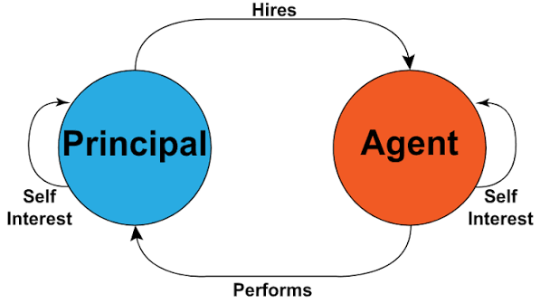

Can the principal observe whether the agent follows its goals?

## Several principals, conflicting demands

[figure not shown]

**Whose instructions govern when the firm and user disagree?**

## You write the lab’s instruction

**Hypothetical:** a lab asks you to write rules for a new model.

1. Write two sentences about what it should do
2. Compare with a partner
3. Find a conflict between the lab, a user and a government

5 minutes · paper or quiet reflection · no account or paid tool needed

## Put the mechanisms together

**Return to one AI case.**

- Who controls a scarce resource?
- Through which channel could it affect a decision?
- Whose rules govern the model?
- What evidence would change your interpretation?